# Statistical Principles and Experimental Design — Seminar 1b: Graphics and Matrix Calcuation in R

matthias.kuhn@tu-dresden.de

October 19, 2023 <sub>[39e18ee]</sub>

**(solutions interspersed)**

## Data Exploration

In the previous exercises, you have seen how to calculate descriptive measures of a sample (like mean or inter-quartile range IQR).

*Plotting* is a very good and intuitive way to show the key characteristics of your data *at a glance*, i.e. a human brain is much quicker to discern structure in a plot than in a table of numbers. Therefore, **graphical exploration** should be the start of any statistical analysis to better understand your data at hand. Which plots you use for exploration will ultimately depend on your data and how it is scaled. The main distinction is if your measurement is

- **metric-scaled** (e.g., length in mm) *or*
- **categorical** (e.g., hair colour brown vs black vs blond which is unordered. Or the likert scale that is categorical and ordered).

### Plotting in R

R is a versatile plotting tool that can produce publication-quality graphics. In the previous handout, we have already explained to you that there are currently *two* widely used ways to produce graphics in R:

1. Base graphics that have been around in R from the beginning. It offers a wealth of specialised plotting functions that each typically have plenty of options to fine-tune the output.
2. [`ggplot2`-package](https://ggplot2.tidyverse.org/) that allows you to create graphics *declaratively*, i.e., you declare your graphic intent and you gradually build up your plot layer by layer. `ggplot2` takes care of the implementation.

Here, we use **`ggplot2`** to produce the basic types of plots (boxplot, histogram and scatterplot) to explore a real data set. First off, load the `ggplot2`-package in your R-session so that all its functions are directly available to you:

```r
library("ggplot2")
```

If the package is not available to your R-session you need to install it *once* via `install.packages("ggplot2")` from the public R-package repository [CRAN](https://cran.r-project.org/web/packages/index.html).

### Malginant Melanoma Study

Fisher & van Belle (1993) report mortality rates due to malignant melanoma of the skin for white males during the period 1950-1969, for each state on the US mainland. The data set is part of the R-package `HSAUR3`, which you can install on your computer from CRAN with the command `install.packages('HSAUR3')`. If this package is installed on your computer you can load the data into your current R-session via

```r
data("USmelanoma", package = "HSAUR3")
```

Alternatively, a tab-delimited text file containing the data can be found at the online course material and loaded into the R-session using RStudio’s «Import Dataset»-wizard in its Environment-window.

The R help page from the package `HSAUR3` has the full details to the data set:

```r
help('USmelanoma', package = 'HSAUR3')
```

Your job is to explore whether and how any of the three covariates (*latitude*, *longitude* and *ocean*) influence the mortality rate.

### Histogram and Boxplots

To get a visual overview over sample data of a single *metric* measurement, both, a histogram and a boxplot are suitable.

Make a histogram and a boxplot for the observed mortality rates across all US-states. Interpret the plots. Also add a title to the plots.

Use the functions `geom_histogram` and `geom_boxplot`. The `ggplot2`-function `labs` allows to add an additional layer to set a title for the plots. Issue `?labs` in the R-console to open its help page.

#### Solution

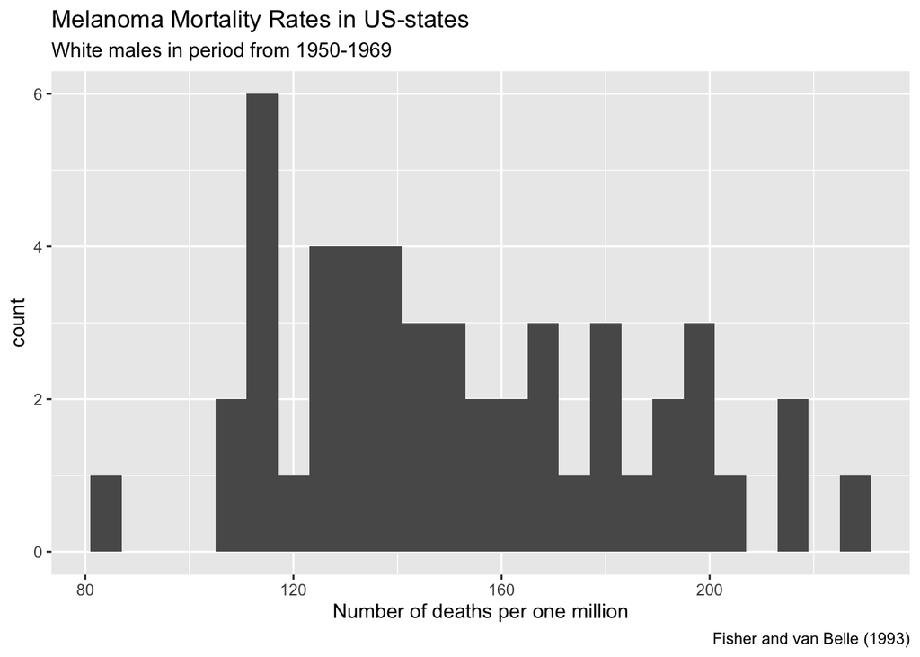

```r
ggplot(data = USmelanoma, mapping = aes(x=mortality)) +
  geom_histogram(binwidth = 6) + # adjust binwidth to your liking
  labs(title = "Melanoma Mortality Rates in US-states",
       subtitle = "White males in period from 1950-1969",
       caption = "Fisher and van Belle (1993)",
       x = "Number of deaths per one million")
```

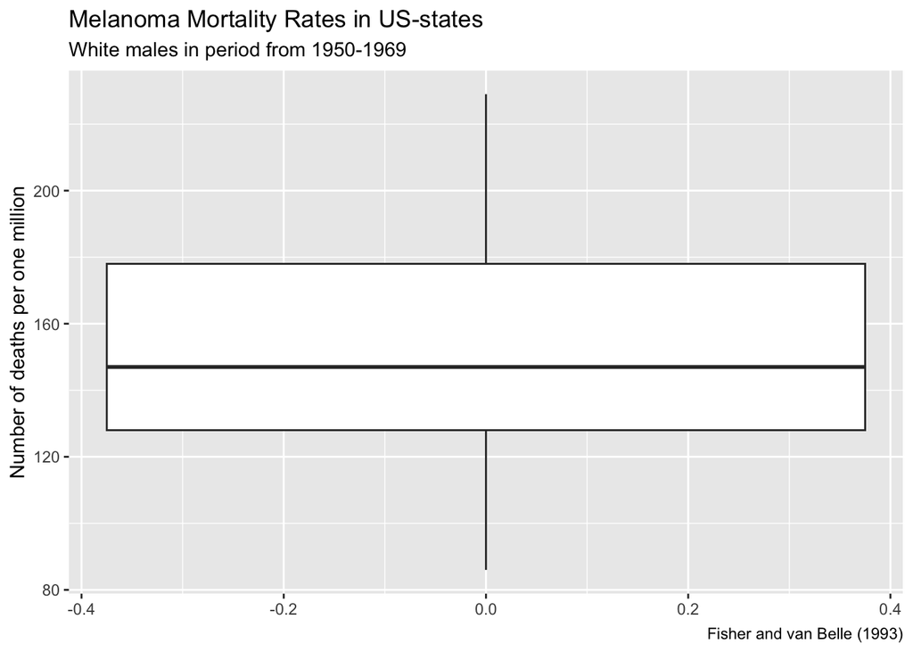

```r
ggplot(data = USmelanoma, mapping = aes(y=mortality)) +
  geom_boxplot() +
  labs(title = "Melanoma Mortality Rates in US-states",
       subtitle = "White males in period from 1950-1969",
       caption = "Fisher and van Belle (1993)",
       y = "Number of deaths per one million")
```

Both plots show the distribution of observed mortality rates across the US-states. Median mortality rate is close to 150 (cf. the median line within the box of the boxplot) and a right-skew in the distribution of the values is visible, particularly in the histogram. Correspondingly, the median line of the boxplot lies not in the middle but rather in the lower part of the box of the boxplot.

What does the following code do?

```r
# common elements for the plots
ggp <- ggplot(USmelanoma, aes(x=mortality)) +
  xlim(80.5, 234.5) # xlim is short for scale_x_continuous(limits = c(80.5, 234.5))

ggbp <- ggp + geom_boxplot() +
  labs(x=NULL)

gghist <- ggp +
  geom_histogram(mapping = aes(y = after_stat(density)), binwidth = 7) +
  geom_density(colour = 'red')

# package patchwork provides function plot_layout
# install it first if not done yet for your R-installation
library("patchwork")
ggbp + gghist +
  plot_layout(nrow = 2, heights = c(1, 4))
```

Note that two different plots are generated based on a shared plot object which we call here `ggp`. The R-package `patchwork` is used to arrange the two ggplot2-graphics in a single column.

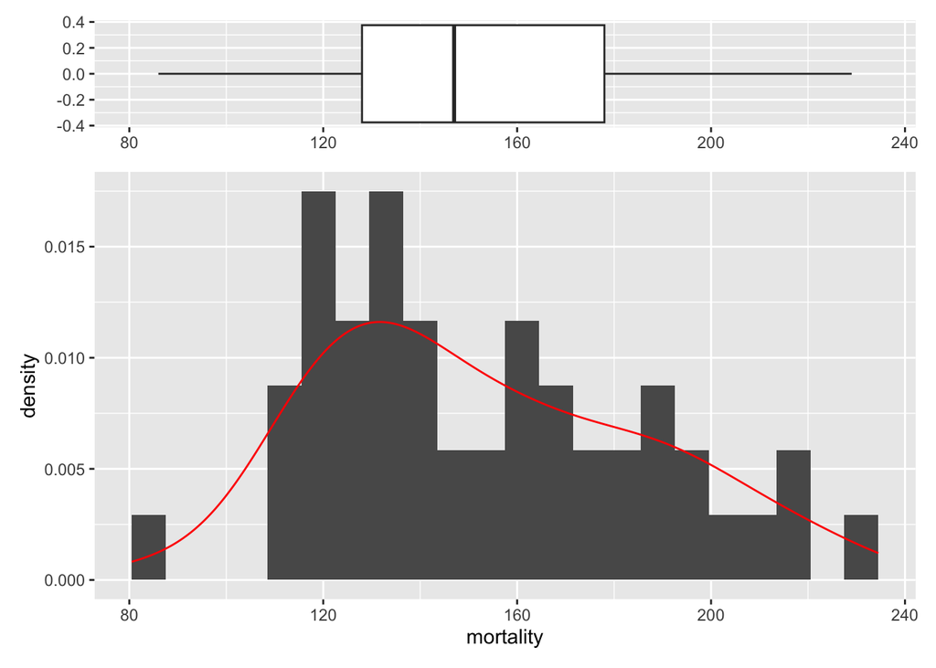

#### Solution

The boxplot is shown horizontally atop the histogram. The x-axes of both plots are aligned by setting common limits via `xlim`. A smooth estimate of the density of mortality rate is superimposed onto the histogram by means of `geom_density`. For this to work, we request the histogram to be on density-scale (instead of the default count-scale) via `y=after_stat(density)` in its mapping. The modifier function `after_stat` is necessary here because the density estimate is not directly available from the data but is only available after the histogram has done its work of categorization and counting of the measurements. Finally, the R-package `patchwork` allows to add up `ggplot`-objects. With its function `plot_layout` you can specify how the plots are arranged.

What happens if you add `+ theme_void()` to the boxplot-object `ggbp`?

The boxplot is shown without any decoration, i.e., no axes. This comes in handy because the y-axis of the boxplot bears no meaning and the x-axes of both plots are aligned anyways and the x-axis of the histogram suffices.

To visually compare the mortality rates of ocean versus non-ocean states you can use a **parallel boxplot**: just specify the grouping factor for one of the axes in the data mapping.

```r
ggplot(data=USmelanoma, mapping = aes(x = ocean, y = mortality)) +
  geom_boxplot() +
  labs(x="Contiguous to an ocean?", y="Mortality Rate")
```

Run this code and view the resulting plot. What are your conclusions from the plot?

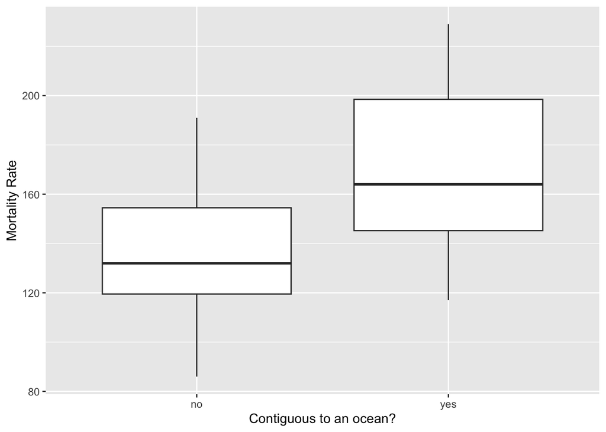

#### Solution

States close to the ocean show a higher mortality rate. Their median mortality rate is around 160 compared to 130 for «non-ocean» states.

### Density plots

For a histogram, the metric measurement is categorized into adjacent bins and the counts per bin visualize the distribution of the measurement.

A density plot is similar but instead of binning the distribution density $f$ is estimated as a smooth line. Using a sliding window approach, for a point $x$ only observations from the its near neighbourhood are considered for the density estimation $f(x)$.

Please plot two separate estimated density lines for *ocean*- and *non-ocean* states in a single plot.

Use the `ggplot2`-function `geom_density` to plot a density-estimate. Simply map the `ocean` column to the aesthetic property «colour» and you get separate density estimates, one for ocean states and one for non-ocean states separately. `ggplot2` will automatically add a legend for you.

#### Solution

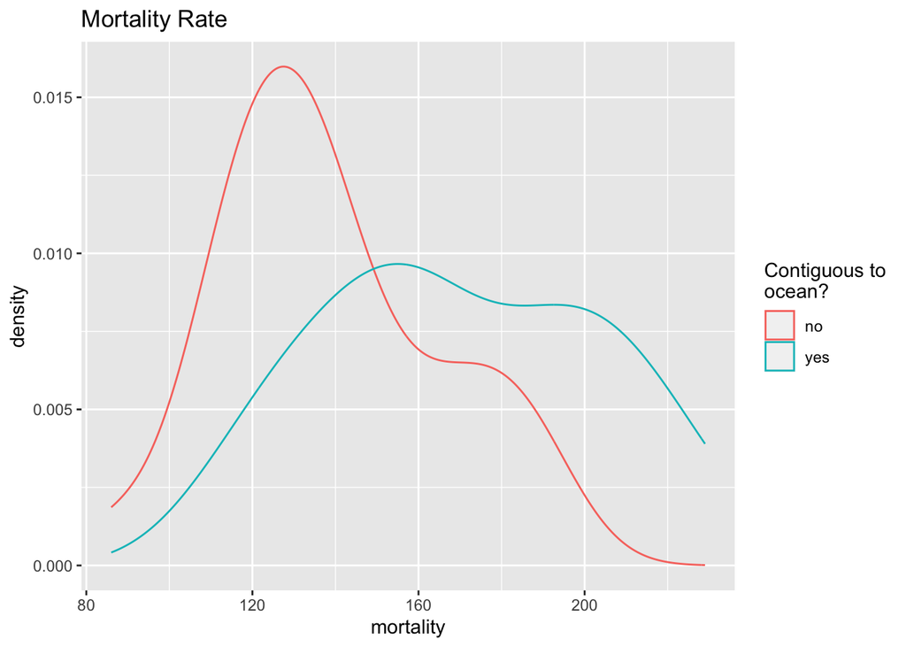

```r
ggplot(USmelanoma, aes(x = mortality, colour = ocean)) +
  geom_density() +
  labs(title = 'Mortality Rate', colour = 'Contiguous to\nocean?')
```

The density plot shows similar information as the previous parallel boxplot, although the difference in *shape* of mortality rate distribution in the two subgroups is visible here more clearly: ocean-states show higher variability than non-ocean states.

### Scatter plot

Consider now the influence of the geographic location of the states on mortality rate. All three variables `longitude`, `latitude` and `mortality` are on metric scale, so scatterplots are a suitable to visualize the bivariate relationships. As mortality is our variable of interest it should go on the y-axis.

Produce two scatterplots mortality vs. longitude *and* mortality vs. latitude

`geom_point` produces scatterplots. Use `plot_layout` from the R-package `patchwork` again to position both plots side by side.

#### Solution

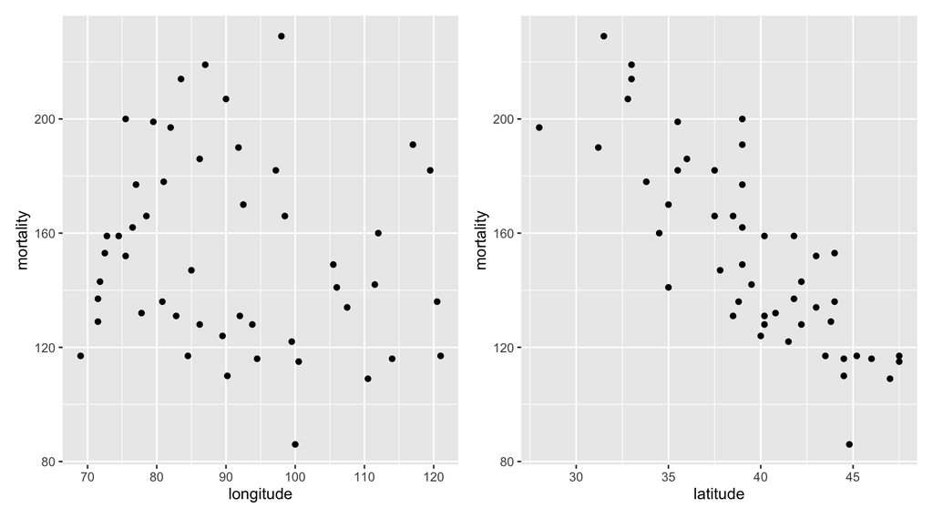

```r
ggsc <- ggplot(USmelanoma, aes(y = mortality))

# package patchwork lets you put plots side simply by side using +
ggsc + geom_point(aes(x = longitude)) +
ggsc + geom_point(aes(x = latitude))
```

Add the ocean information to both scatterplots by means of colour and plotting symbol. How do you interpret these final two plots?

Map the `colour=` and `shape=` aesthetics appropriately.

#### Solution

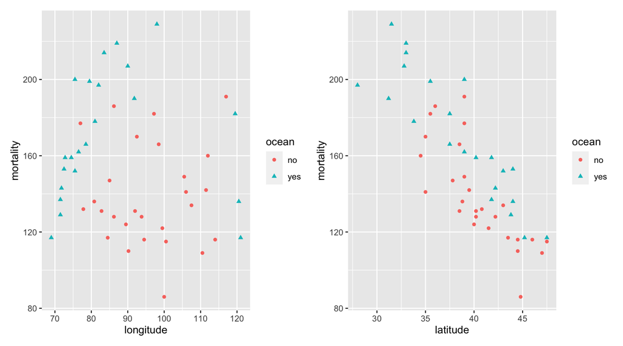

```r
# common plot features stored in object ggsc
ggsc <- ggplot(USmelanoma, aes(y = mortality, col = ocean, shape = ocean))

ggsc + geom_point(aes(x = longitude)) +
ggsc + geom_point(aes(x = latitude))
```

Longitude and mortality rate appear to be uncorrelated. The plot reflects the geographic fact that the US has an east and a west coast.  
We discover a strong linear relationship between latitude and mortality rate: the more south a state the higher the mortality rate. The ocean effect is also visible here and seems to act independently of the latitude effect as the ocean states (turquoise triangles) appear to be shifted upwards.

## Matrix calculations in R

In this section, we want to explore some of R’s built-in matrix operations and come up with two examples of systems of linear equations that can be solved through matrix calculations.

### Hospital beds

Imagine that it is known that a hospital has a capacity of 580 beds which are distributed in 200 rooms that are equipped with either two or three beds.

How many 2- and 3-bed rooms does the hospital have?

To solve this question, first define the unknown variables and then write down the given information. Together, the information forms a system of equations which can be represented as a single matrix equation in the form **A · x = b** where

- **A** is a matrix of coefficients
- **x** is the vector to the unknown variables
- **b** is the result vector

Use R’s linear algebra facilities (e.g. see [here](https://www.statmethods.net/advstats/matrix.html)) to solve this equation.

```r
# define coefficient matrix
A <- matrix(c(2, 3,  # total number of beds
              1, 1), # total number of rooms
            byrow = TRUE, ncol = 2,
            dimnames = list(NULL, c("nbr2bed", "nbr3bed")))

# define result vector
b <- c(580, 200)
# get solution x of equation A · x = b
sol <- solve(A, b)
```

There are two unknown variables:  
1. the number of 2-bed rooms  
2. the number of 3-bed rooms.

The solution is given in the following table:

Solution

| Variable | Value |
| --- | --- |
| nbr2bed | 20 |
| nbr3bed | 180 |

### Electricity in a network

[interactive chart not shown]

In the sketched electrical circuit the current *I* and the resistance values *R<sub>j</sub>* (j=1,…,5) are known:

| Variable | Value |
| --- | --- |
| I | 4 A |
| R1 | 4 Ω |
| R2 | 5.5 Ω |
| R3 | 0.5 Ω |
| R4 | 5 Ω |
| R5 | 4 Ω |

Kirchhoff’s circuit law says that

1. At any node in an electrical circuit, the sum of currents flowing *into* that node is equal to the sum of currents flowing *out* of that node.
2. The directed sum of the electrical potential differences (voltage) around any closed network is zero.

When electrical potential difference $U$ is the product of current $I$ and resistance $R$, i.e. $U = I \cdot R$, calculate the value for the currents I<sub>1</sub>, … , I<sub>5</sub> using Kirchhoff’s law.

First we define a vector, which we call VALS, that holds the given values:

```r
VALS <-  c(I = 4, R1 = 4, R2 = 5.5, R3 = 0.5, R4 = 5, R5 = 4)
```

```r
# the vector x has 5 elements and consists of I1, .., I5
# coefficient matrix
A <- matrix(c(1, 1, 0, 0, 0,     # green node: given fixed I = I1 + I2 (KCL1)
              0, 1, -1, -1, 0,   # blue node: I2 = I3 + I4 (KCL1)
              1, 0, 1, 0, -1,    # red node: I1 + I3 = I5 (KCL1)
              -VALS["R1"], VALS["R2"], VALS["R3"], 0, 0,  # lower left circuit (KCL2)
              0, 0, VALS["R3"], -VALS["R4"], VALS["R5"]), # upper right circuit (KCL2)
            byrow = TRUE, ncol = 5,
            dimnames = list(NULL, c("I1", "I2", "I3", "I4", "I5")))
# result vector
b <- c(VALS["I"], 0, 0, 0, 0)
# solve linear equations simultaneously
sol <- solve(A, b)
```

The solution consists of five variables: I<sub>1</sub>, I<sub>2</sub>, I<sub>3</sub>, I<sub>4</sub> *and* I<sub>5</sub>. You have to ensure that you do not carry redundant equations in the matrix. We need as many equations as we have variables. The rounded solutions are given in the following table:

Solution

| Variable | Value |
| --- | --- |
| I1 | 2.311 |
| I2 | 1.689 |
| I3 | -0.084 |
| I4 | 1.773 |
| I5 | 2.227 |